# Área y perímetro de figuras geométricas

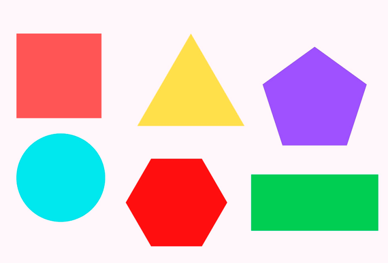

## Área y perímetro de figuras geométricas

Observa este [video](https://www.youtube.com/watch?v=wYNvY_bOGdc) donde hay una breve explicación sobre área y perímetro de una figura.

## 🔁 Actividad 1

Repasa lo aprendido y escribe el siguiente texto en forma completa poniendo una sola palabra en los espacios vacíos:

*El perímetro es la ______ que rodea una figura. Imagina que quieres poner un hilo alrededor de un jardín: la longitud de ese hilo es el ______. Para calcularlo se ______ todos los lados de la figura. Se mide en unidades de longitud: metros, centímetros, etc.*

*El ______ es la medida de la superficie que ocupa una figura, o sea, cuánto espacio hay dentro de la ______. Piensa en cuántas baldosas caben para cubrir un ______: eso es el área. Para calcularla debes aplicar la fórmula específica según la figura. Se mide en unidades de superficie: metros ______, centímetros cuadrados, etc.*

## Actividad 2

(sin autocorrección)

El perímetro se calcula simplemente sumando los lados y, salvo para la circunferencia, no hace falta acordarse una fórmula especial para calcularlo. En cambio para calcular el área de una figura hay fómrulas específicas. En el video aparecen dos, la del rectángulo y la del triángulo. Busca información y dibuja las siguientes figuras poniéndo al lado la fórmula para calcular su área: cuadrado, círculo y trapecio.

## 🔁 Actividad 3

Resolver los siguientes problemas de perímetros:

**a)** Encontrar el perímetro de la siguiente figura. Recordar que el perímetro de una circunferencia entera es $P = 2 \cdot \pi \cdot r$ donde $\pi = 3,14$

[figure not shown]

**b)** Se quiere alambrar el terreno de cultivo de una granja que tiene la forma de la figura ¿Cuántos metros de malla de alambre hay que comprar?

[figure not shown]

## 🔁 Actividad 4

Resolver los siguientes problemas de área (puedes usar calculadora aquí):

**a)** Una piscina tiene una forma circular con 15 metros de radio. ¿Cuál es la superficie del círculo formado por la pileta?

[figure not shown]

**b)** Una lona tiene una forma triangular como se muestra en la figura en donde su base “b” tiene 120 cm y la altura “h” 110 cm ¿Cuántos centímertos cuadrados mide la superficie de la lona?

[figure not shown]

**c)** Una cancha de fútbol tiene forma rectangular como se muestra en la figura. Si la base mide 80 metros y la altura 50 metros ¿cuántos metros cuadrados mide la superficie de la cancha?

[figure not shown]

**d)** Un piscina tiene una forma compuesta por un rectángulo y un semi-círculo tal como se muestra en la figura. Cálcular el área que ocupa la pileta.

[figure not shown]

**Soluciones para autocorregirte**

### Actividad 1

El perímetro es la *distancia* que rodea una figura. Imagina que quieres poner un hilo alrededor de un jardín: la longitud de ese hilo es el *perímetro*. Para calcularlo se *suman* todos los lados de la figura. Se mide en unidades de longitud: metros, centímetros, etc.

El *área* es la medida de la superficie que ocupa una figura, o sea, cuánto espacio hay dentro de la *figura*. Piensa en cuántas baldosas caben para cubrir un *piso*: eso es el área. Para calcularla debes aplicar la fórmula específica según la figura. Se mide en unidades de superficie: metros *cuadrados*, centímetros cuadrados, etc.

### Actividad 3

**a)**

- Perímetro media circunferencia: $\frac{2 \pi r}{2}$ = $3,14 \cdot r$ = 31,4 m
- Perímetro total = 31,4 m + 10 m + 8 m + 10 m = **59,4 m**

**b)**

- Falta conocer un lado y este es: 180 m - 70 m = 110 m
- Perímetro total = 110 m + 130 m + 70 m + 130 m + 180 m = **620 m**

Rta: Se necesitan 620 metros de malla de alambre.

### Actividad 4

**a)**

Área piscina = área círculo = $\pi \cdot r^2$ = $3,14 \cdot (15m)^2$ = **706,5** $m^2$

Rta: El área del círculo formado por la pileta es t06,5 metros cuadrados

**b)**

Área lona = área triángulo = $\frac{b \cdot h}{2}$ = $\frac{120 cm \cdot 110 cm}{2}$ = **6600** $cm^2$

Rta: La lona tiene 6600 centímetros cuadrados

**d)**

Área piscina = área rectángulo + área semi-círculo

área reactángulo = $8 m \cdot 15 m$ = **120** $m^2$

área semi-círculo = $\frac{\pi \cdot r^2}{2}$ = $\frac{3,14 \cdot (4m)^2}{2}$ = **25,12** $m^2$

- El radio es igual a la mitad de la altura del rectángulo

Área total = 120 $m^2$ + 25,12 $m^2$ = **145,12** $m^2$

Rta: La pileta ocupa un área de 145,12 metros cuadrados